# Analyzing World Happines Data

### By: Matthew McIntyre

In this tutorial, I will analyze data from the World Happiness Report for 2021. The [World Happiness Report](https://worldhappiness.report/archive/) contains happiness rankings of countries around the world. The polling to collect the happiness data is done by Gallup and published in the Gallup World Poll (GWP). The GWP has a section about global happiness data called the "[Gallup Global Happiness Center](https://www.gallup.com/analytics/349487/gallup-global-happiness-center.aspx)".

The goal of this tutorial is to analyze factors that affect the happiness in a country. During this tutorial, I will walk through the phases of the data science pipeline to help me analyze the data and derive useful insights from that analysis.

```python
!pip3 install openpyxl
```

```python
import pandas as pd
import numpy as np
from sklearn.linear_model import LinearRegression
import matplotlib.pyplot as plt
from sklearn.impute import KNNImputer
```

## Data Collection

Data collection is the first step in the data science pipeline. It is self explanatory: collect the data that you want to analyze. Below are the data that I chose to analyze.

```python
# read files into a pandas DataFrame
happiness_rankings_df = pd.read_excel('DataForFigure2.1WHR2021C2.xls')
historical_scores_df = pd.read_excel('DataPanelWHR2021C2-2.xls')
education_index_df = pd.read_csv('Education_index.csv')
depression_rates_df = pd.read_csv('csvData.csv')
```

```python
happiness_rankings_df.head()
```

|  | Country name | Regional indicator | Ladder score | Standard error of ladder score | upperwhisker | lowerwhisker | Logged GDP per capita | Social support | Healthy life expectancy | Freedom to make life choices | Generosity | Perceptions of corruption | Ladder score in Dystopia | Explained by: Log GDP per capita | Explained by: Social support | Explained by: Healthy life expectancy | Explained by: Freedom to make life choices | Explained by: Generosity | Explained by: Perceptions of corruption | Dystopia + residual |
| --- | --- | --- | --- | --- | --- | --- | --- | --- | --- | --- | --- | --- | --- | --- | --- | --- | --- | --- | --- | --- |
| 0 | Finland | Western Europe | 7.8421 | 0.031646 | 7.904126 | 7.780075 | 10.775202 | 0.953603 | 72.000000 | 0.949268 | -0.097760 | 0.185846 | 2.430343 | 1.446356 | 1.106192 | 0.740824 | 0.690577 | 0.124200 | 0.480524 | 3.253415 |
| 1 | Denmark | Western Europe | 7.6195 | 0.034657 | 7.687428 | 7.551572 | 10.933176 | 0.954410 | 72.699753 | 0.945639 | 0.030109 | 0.178838 | 2.430343 | 1.501548 | 1.108008 | 0.762862 | 0.686160 | 0.207615 | 0.484993 | 2.868296 |
| 2 | Switzerland | Western Europe | 7.5715 | 0.036243 | 7.642536 | 7.500463 | 11.117368 | 0.941742 | 74.400101 | 0.918788 | 0.024629 | 0.291698 | 2.430343 | 1.565899 | 1.079469 | 0.816415 | 0.653488 | 0.204040 | 0.413019 | 2.839148 |
| 3 | Iceland | Western Europe | 7.5539 | 0.059373 | 7.670271 | 7.437528 | 10.877768 | 0.982938 | 73.000000 | 0.955123 | 0.160274 | 0.672865 | 2.430343 | 1.482190 | 1.172279 | 0.772319 | 0.697701 | 0.292526 | 0.169940 | 2.966945 |
| 4 | Netherlands | Western Europe | 7.4640 | 0.027326 | 7.517559 | 7.410441 | 10.931812 | 0.941601 | 72.400116 | 0.913116 | 0.175404 | 0.337938 | 2.430343 | 1.501072 | 1.079151 | 0.753425 | 0.646585 | 0.302397 | 0.383531 | 2.797818 |

The above table ranks countries based on their "ladder score", which we can think of as the happiness score. The score ranges from 0 to 10 where 0 is the least happy and 10 is the most happy. This table is from the [World Happiness Report 2021](https://worldhappiness.report/ed/2021/) page in the "Appendices & Data" section.

```python
historical_scores_df.sort_values(by = 'Life Ladder', ascending = False).head()
```

|  | Country name | year | Life Ladder | Log GDP per capita | Social support | Healthy life expectancy at birth | Freedom to make life choices | Generosity | Perceptions of corruption | Positive affect | Negative affect |
| --- | --- | --- | --- | --- | --- | --- | --- | --- | --- | --- | --- |
| 449 | Denmark | 2005 | 8.018934 | 10.851397 | 0.972372 | 69.599998 | 0.971135 | NaN | 0.236522 | 0.859549 | 0.153672 |
| 451 | Denmark | 2008 | 7.970892 | 10.880102 | 0.953912 | 70.080002 | 0.969788 | 0.272087 | 0.247505 | 0.756866 | 0.163091 |
| 563 | Finland | 2020 | 7.889350 | 10.750446 | 0.961621 | 72.099998 | 0.962424 | -0.115532 | 0.163636 | 0.744292 | 0.192898 |
| 561 | Finland | 2018 | 7.858107 | 10.782932 | 0.962155 | 71.900002 | 0.937807 | -0.127380 | 0.198605 | 0.781546 | 0.181781 |
| 450 | Denmark | 2007 | 7.834233 | 10.891111 | 0.954201 | 69.919998 | 0.932086 | 0.240024 | 0.206006 | 0.827860 | 0.194324 |

The above table contains historical happiness scores dating back to 2005 for some countries (not every country participated in the poll every year). This table is from the [World Happiness Report 2021](https://worldhappiness.report/ed/2021/) page in the "Appendices & Data" section.

```python
education_index_df.head()
```

|  | HDI Rank | Country | 1990 | Unnamed: 3 | 1991 | Unnamed: 5 | 1992 | Unnamed: 7 | 1993 | Unnamed: 9 | ... | 2015 | Unnamed: 53 | 2016 | Unnamed: 55 | 2017 | Unnamed: 57 | 2018 | Unnamed: 59 | 2019 | Unnamed: 61 |
| --- | --- | --- | --- | --- | --- | --- | --- | --- | --- | --- | --- | --- | --- | --- | --- | --- | --- | --- | --- | --- | --- |
| 0 | 169 | Afghanistan | 0.122 | NaN | 0.133 | NaN | 0.145 | NaN | 0.156 | NaN | ... | 0.405 | NaN | 0.406 | NaN | 0.408 | NaN | 0.413 | NaN | 0.414 | NaN |
| 1 | 69 | Albania | 0.583 | NaN | 0.588 | NaN | 0.557 | NaN | 0.542 | NaN | ... | 0.753 | NaN | 0.745 | NaN | 0.747 | NaN | 0.743 | NaN | 0.746 | NaN |
| 2 | 91 | Algeria | 0.385 | NaN | 0.395 | NaN | 0.405 | NaN | 0.414 | NaN | ... | 0.659 | NaN | 0.660 | NaN | 0.665 | NaN | 0.668 | NaN | 0.672 | NaN |
| 3 | 36 | Andorra | .. | NaN | .. | NaN | .. | NaN | .. | NaN | ... | 0.718 | NaN | 0.722 | NaN | 0.713 | NaN | 0.720 | NaN | 0.720 | NaN |
| 4 | 148 | Angola | .. | NaN | .. | NaN | .. | NaN | .. | NaN | ... | 0.472 | NaN | 0.487 | NaN | 0.498 | NaN | 0.500 | NaN | 0.500 | NaN |

5 rows × 62 columns

The above table is the education index from the Human Development Reports. On the Human Development Reports website, they provide the following definition: "Education index is an average of mean years of schooling (of adults) and expected years of schooling (of children), both expressed as an index obtained by scaling with the corresponding maxima." A higher score means more education. The table contains scores from 1990 to 2019 but some countries have no data for some years as you can see in the table. Click [here](http://hdr.undp.org/en/humandev) to read more about the Human Development Reports. Click [here](http://hdr.undp.org/en/indicators/103706) to view the education index in full.

```python
depression_rates_df = depression_rates_df.rename(columns = {'country' : 'Country name'})
depression_rates_df.head()
```

|  | Country name | prevalence | cases | pop2021 |
| --- | --- | --- | --- | --- |
| 0 | Ukraine | 6.3 | 2800587 | 43466.819 |
| 1 | Estonia | 5.9 | 75667 | 1325.185 |
| 2 | Australia | 5.9 | 1318599 | 25788.215 |
| 3 | United States | 5.9 | 17491047 | 332915.073 |
| 4 | Brazil | 5.8 | 11548577 | 213993.437 |

The above table lists depression rates for countries. This table was from worldpopulationreview.com. The data in the table is from the [World Health Organization](https://www.who.int). To read more about depression rates by country, click [here](https://www.who.int/publications/i/item/depression-global-health-estimates). This is a 2017 study done by the World Health Organization; worldpopulationreview.com falsely states that this data is from 2021. I could not find any studies from a more recent year

## Data Processing

During the data processing step of the data science pipeline, the collected data is prepared for analysis. Here I will choose columns that have the data I want and put them into one table so the data is easy to access. I will also handle missing data and reorganize tables if necessary. The data processing step of the data science pipeline is usually the longest among the other steps.

```python
education_index_df.head()
```

|  | HDI Rank | Country | 1990 | Unnamed: 3 | 1991 | Unnamed: 5 | 1992 | Unnamed: 7 | 1993 | Unnamed: 9 | ... | 2015 | Unnamed: 53 | 2016 | Unnamed: 55 | 2017 | Unnamed: 57 | 2018 | Unnamed: 59 | 2019 | Unnamed: 61 |
| --- | --- | --- | --- | --- | --- | --- | --- | --- | --- | --- | --- | --- | --- | --- | --- | --- | --- | --- | --- | --- | --- |
| 0 | 169 | Afghanistan | 0.122 | NaN | 0.133 | NaN | 0.145 | NaN | 0.156 | NaN | ... | 0.405 | NaN | 0.406 | NaN | 0.408 | NaN | 0.413 | NaN | 0.414 | NaN |
| 1 | 69 | Albania | 0.583 | NaN | 0.588 | NaN | 0.557 | NaN | 0.542 | NaN | ... | 0.753 | NaN | 0.745 | NaN | 0.747 | NaN | 0.743 | NaN | 0.746 | NaN |
| 2 | 91 | Algeria | 0.385 | NaN | 0.395 | NaN | 0.405 | NaN | 0.414 | NaN | ... | 0.659 | NaN | 0.660 | NaN | 0.665 | NaN | 0.668 | NaN | 0.672 | NaN |
| 3 | 36 | Andorra | .. | NaN | .. | NaN | .. | NaN | .. | NaN | ... | 0.718 | NaN | 0.722 | NaN | 0.713 | NaN | 0.720 | NaN | 0.720 | NaN |
| 4 | 148 | Angola | .. | NaN | .. | NaN | .. | NaN | .. | NaN | ... | 0.472 | NaN | 0.487 | NaN | 0.498 | NaN | 0.500 | NaN | 0.500 | NaN |

5 rows × 62 columns

As you can see, the education index table is not tidy. There are multiple unnamed columns full of NaN values, the years are columns instead of rows, and there is some missing data.

```python
drops = []

# adding columns to the drops list if it is an unnamed column that needs to be dropped
for col in list(education_index_df.columns):
    if col.find("Unnamed: ") == 0:
        drops.append(col)

# removing unnecessary columns and rows
education_index_df = education_index_df.drop(columns = drops)
education_index_df = education_index_df.drop(list(range(189, 206)))
```

```python
# adding a column for year so that the values for the years are no longer columns but are now values in the Year column
temp = pd.melt(education_index_df, id_vars = ['HDI Rank', 'Country']).sort_values(by = ['Country', 'variable'], ascending = True)
temp = temp.rename(columns = {'variable' : 'Year', 'value' : 'Score'})
education_index_df = temp
```

```python
# resetting the indices for the education index table
education_index_df = education_index_df.reset_index()
education_index_df = education_index_df.drop(columns = ['index'])
education_index_df
```

|  | HDI Rank | Country | Year | Score |
| --- | --- | --- | --- | --- |
| 0 | 169 | Afghanistan | 1990 | 0.122 |
| 1 | 169 | Afghanistan | 1991 | 0.133 |
| 2 | 169 | Afghanistan | 1992 | 0.145 |
| 3 | 169 | Afghanistan | 1993 | 0.156 |
| 4 | 169 | Afghanistan | 1994 | 0.168 |
| ... | ... | ... | ... | ... |
| 5665 | 150 | Zimbabwe | 2015 | 0.560 |
| 5666 | 150 | Zimbabwe | 2016 | 0.565 |
| 5667 | 150 | Zimbabwe | 2017 | 0.568 |
| 5668 | 150 | Zimbabwe | 2018 | 0.570 |
| 5669 | 150 | Zimbabwe | 2019 | 0.587 |

5670 rows × 4 columns

The above code cleans up the table and displays it. There are no columns full of NaN values and now each year value is in a row rather than being a column.

Now I want to combine the data from each table into one main table. I will include columns in the main table that I plan to use in my analysis and exclude columns that I do not plan to use.

```python
# createing a DataFrame with the desired columns from the happiness rankings table.
main_happiness_table = pd.DataFrame(data = {'Country name' : happiness_rankings_df['Country name'],
                                  'Regional indicator' : happiness_rankings_df['Regional indicator'],
                                 'Ladder score' : happiness_rankings_df['Ladder score'],
                                 'Logged GDP per capita' : happiness_rankings_df['Logged GDP per capita'],
                                 'Social Support' : happiness_rankings_df['Social support'],
                                 'Healthy life expectancy' : happiness_rankings_df['Healthy life expectancy'],
                                 'Freedom to make life choices' : happiness_rankings_df['Freedom to make life choices'],
                                 'Perceptions of corruption' : happiness_rankings_df['Perceptions of corruption']})



main_happiness_table.head()
```

|  | Country name | Regional indicator | Ladder score | Logged GDP per capita | Social Support | Healthy life expectancy | Freedom to make life choices | Perceptions of corruption |
| --- | --- | --- | --- | --- | --- | --- | --- | --- |
| 0 | Finland | Western Europe | 7.8421 | 10.775202 | 0.953603 | 72.000000 | 0.949268 | 0.185846 |
| 1 | Denmark | Western Europe | 7.6195 | 10.933176 | 0.954410 | 72.699753 | 0.945639 | 0.178838 |
| 2 | Switzerland | Western Europe | 7.5715 | 11.117368 | 0.941742 | 74.400101 | 0.918788 | 0.291698 |
| 3 | Iceland | Western Europe | 7.5539 | 10.877768 | 0.982938 | 73.000000 | 0.955123 | 0.672865 |
| 4 | Netherlands | Western Europe | 7.4640 | 10.931812 | 0.941601 | 72.400116 | 0.913116 | 0.337938 |

The above code extracts columns from the original happiness rankings table. The original table had 20 columns but I only include 8 in my main table.

```python
# merge the main table with the depression rates table
temp = main_happiness_table.merge(depression_rates_df, on = 'Country name', how = 'left')
# drop the unnecessary columns that came from the depression rates table
temp = temp.drop(columns = ['cases', 'pop2021'])
temp = temp.rename(columns = {'prevalence' : 'depression rate'})
main_happiness_table = temp
main_happiness_table.head()
```

|  | Country name | Regional indicator | Ladder score | Logged GDP per capita | Social Support | Healthy life expectancy | Freedom to make life choices | Perceptions of corruption | depression rate |
| --- | --- | --- | --- | --- | --- | --- | --- | --- | --- |
| 0 | Finland | Western Europe | 7.8421 | 10.775202 | 0.953603 | 72.000000 | 0.949268 | 0.185846 | 5.6 |
| 1 | Denmark | Western Europe | 7.6195 | 10.933176 | 0.954410 | 72.699753 | 0.945639 | 0.178838 | 5.0 |
| 2 | Switzerland | Western Europe | 7.5715 | 11.117368 | 0.941742 | 74.400101 | 0.918788 | 0.291698 | 5.0 |
| 3 | Iceland | Western Europe | 7.5539 | 10.877768 | 0.982938 | 73.000000 | 0.955123 | 0.672865 | 4.1 |
| 4 | Netherlands | Western Europe | 7.4640 | 10.931812 | 0.941601 | 72.400116 | 0.913116 | 0.337938 | 4.7 |

The above code merges the main table with the depression rates table. I do this so that I have the depression rates for each country in my table. I remove unnecessary rows and display the updated main table.

```python
# casting Year and Score columns as integers and floats respectively
education_index_df = education_index_df.astype({'Year': 'int32', 'Score' : 'float32'}, errors = 'ignore')
```

The education index table has scores from 1990 to 2019 but I want data for 2021. I can use the historical data to construct a linear model that can predict the scores for 2021 for each country.

```python
education_index_df.groupby('Country').all()
```

| Country | HDI Rank | Year | Score |
| --- | --- | --- | --- |
| Afghanistan | True | True | True |
| Albania | True | True | True |
| Algeria | True | True | True |
| Andorra | True | True | True |
| Angola | True | True | True |
| ... | ... | ... | ... |
| Venezuela (Bolivarian Republic of) | True | True | True |
| Viet Nam | True | True | True |
| Yemen | True | True | True |
| Zambia | True | True | True |
| Zimbabwe | True | True | True |

189 rows × 3 columns

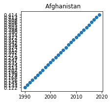

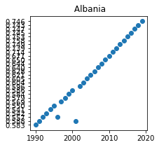

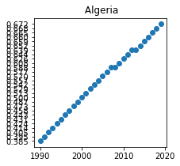

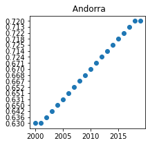

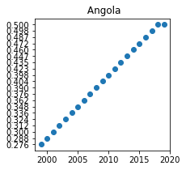

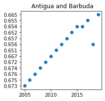

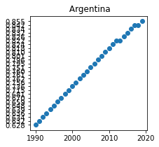

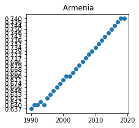

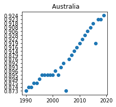

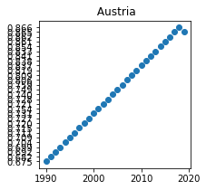

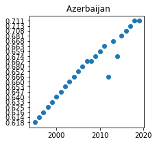

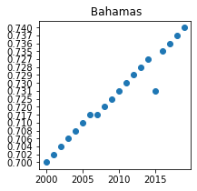

[177 more figures not shown]

```python
# map the country to the 2021 predicted score
edu_score_2021 = pd.Series(dtype = 'float32')

for country, info in education_index_df.groupby('Country'):
    # get scores and years from each country, ignoring years where the country has no score
    X = np.array(info.loc[info['Score'] != '..', 'Year'])
    y = np.array(info.loc[info['Score'] != '..', 'Score'])
    # use the year as a predictor for the score and make a prediction for the 2021 score using linear regression
    lin_model = LinearRegression()
    lin_model.fit(X.reshape(-1, 1), y)
    # make a scatter plot of year vs score for each country to see if the relationship is linear
    plt.figure(figsize = (3, 3))
    plt.scatter(X, y)
    plt.title(country)
    plt.show()
    # pair up the country with its 2021 predicted score in the Series object
    edu_score_2021.loc[country.strip()] = lin_model.predict(np.array(2021).reshape(1, -1))[0]
```

In the above code, I use the DataFrame groupby() method to loop through each country individually and make a linear regression predction for their 2021 education index score. I use the years to predict the score. I also produced a scatter plot for each country where year is on the x axis and the score is on the y axis. I did this to verify that there is a linear relationship beween year and score. The country and predicted 2021 score are paired up in a pandas Series object.

Now that I have the predicted scores for 2021, I can append these scores to my main table.

```python
# create a DataFrame object from the edu_score_2021 Series object
temp1 = pd.DataFrame(data = edu_score_2021)
temp1 = temp1.reset_index()
temp1 = temp1.rename(columns = {'index' : 'Country name', 0 : '2021 edu index'})
# merge the main table with the table containing the 2021 edu index
main_happiness_table = main_happiness_table.merge(temp1, on = 'Country name', how = 'left')
main_happiness_table
```

|  | Country name | Regional indicator | Ladder score | Logged GDP per capita | Social Support | Healthy life expectancy | Freedom to make life choices | Perceptions of corruption | depression rate | 2021 edu index |
| --- | --- | --- | --- | --- | --- | --- | --- | --- | --- | --- |
| 0 | Finland | Western Europe | 7.8421 | 10.775202 | 0.953603 | 72.000000 | 0.949268 | 0.185846 | 5.6 | 0.991178 |
| 1 | Denmark | Western Europe | 7.6195 | 10.933176 | 0.954410 | 72.699753 | 0.945639 | 0.178838 | 5.0 | 0.987285 |
| 2 | Switzerland | Western Europe | 7.5715 | 11.117368 | 0.941742 | 74.400101 | 0.918788 | 0.291698 | 5.0 | 0.940509 |
| 3 | Iceland | Western Europe | 7.5539 | 10.877768 | 0.982938 | 73.000000 | 0.955123 | 0.672865 | 4.1 | 0.953761 |
| 4 | Netherlands | Western Europe | 7.4640 | 10.931812 | 0.941601 | 72.400116 | 0.913116 | 0.337938 | 4.7 | 0.936438 |
| ... | ... | ... | ... | ... | ... | ... | ... | ... | ... | ... |
| 144 | Lesotho | Sub-Saharan Africa | 3.5118 | 7.925777 | 0.786871 | 48.700001 | 0.714954 | 0.915377 | 4.8 | 0.542685 |
| 145 | Botswana | Sub-Saharan Africa | 3.4665 | 9.781536 | 0.784171 | 59.269188 | 0.824394 | 0.800619 | 4.7 | 0.709169 |
| 146 | Rwanda | Sub-Saharan Africa | 3.4147 | 7.676118 | 0.552339 | 61.399727 | 0.896758 | 0.166801 | 3.8 | 0.514703 |
| 147 | Zimbabwe | Sub-Saharan Africa | 3.1448 | 7.942595 | 0.750470 | 56.200840 | 0.676700 | 0.820999 | 4.0 | 0.585265 |
| 148 | Afghanistan | South Asia | 2.5229 | 7.694710 | 0.462596 | 52.492615 | 0.381749 | 0.924338 | 3.3 | 0.473132 |

149 rows × 10 columns

The above code adds a column titled 2021 edu index at the end of the table. This is the predicted 2021 educational index computed earlier.

```python
# count NaN values
main_happiness_table['2021 edu index'].isna().sum()
```

```
18
```

The above code counts NaN values in the 2021 edu index column. There are 18 occurences on NaN and they need to be replaced with usable values.

```python
# fill in missing data
main_happiness_table['2021 edu index'] = main_happiness_table['2021 edu index'].fillna(main_happiness_table['2021 edu index'].mean())
# count NaN values
main_happiness_table['2021 edu index'].isna().sum()
```

```
0
```

The above code imputes the missing data with the mean of the column. I recount the NaN values and as you can see now there are no missing values.

```python
historical_scores_df = historical_scores_df.drop(columns = ['Generosity', 'Positive affect', 'Negative affect'])
```

```python
print(historical_scores_df.isna().sum())
print((historical_scores_df.isna().sum().sum() / historical_scores_df.size) * 100)
```

```
Country name                          0
year                                  0
Life Ladder                           0
Log GDP per capita                   36
Social support                       13
Healthy life expectancy at birth     55
Freedom to make life choices         32
Perceptions of corruption           110
dtype: int64
1.577732170343766
```

The above code shows how many missing entries are in each column of the historical happiness scores table. The last number in the output is the percentage of entries that are empty in the table. Fortunately the percentage is small.

```python
historical_scores_df = historical_scores_df.fillna(historical_scores_df.mean())
historical_scores_df.isna().sum()
```

```
Country name                        0
year                                0
Life Ladder                         0
Log GDP per capita                  0
Social support                      0
Healthy life expectancy at birth    0
Freedom to make life choices        0
Perceptions of corruption           0
dtype: int64
```

The above code fills in missing values with the mean and shows that there are now no missing values in teh table.

```python
main_happiness_table
```

|  | Country name | Regional indicator | Ladder score | Logged GDP per capita | Social Support | Healthy life expectancy | Freedom to make life choices | Perceptions of corruption | depression rate | 2021 edu index |
| --- | --- | --- | --- | --- | --- | --- | --- | --- | --- | --- |
| 0 | Finland | Western Europe | 7.8421 | 10.775202 | 0.953603 | 72.000000 | 0.949268 | 0.185846 | 5.6 | 0.991178 |
| 1 | Denmark | Western Europe | 7.6195 | 10.933176 | 0.954410 | 72.699753 | 0.945639 | 0.178838 | 5.0 | 0.987285 |
| 2 | Switzerland | Western Europe | 7.5715 | 11.117368 | 0.941742 | 74.400101 | 0.918788 | 0.291698 | 5.0 | 0.940509 |
| 3 | Iceland | Western Europe | 7.5539 | 10.877768 | 0.982938 | 73.000000 | 0.955123 | 0.672865 | 4.1 | 0.953761 |
| 4 | Netherlands | Western Europe | 7.4640 | 10.931812 | 0.941601 | 72.400116 | 0.913116 | 0.337938 | 4.7 | 0.936438 |
| ... | ... | ... | ... | ... | ... | ... | ... | ... | ... | ... |
| 144 | Lesotho | Sub-Saharan Africa | 3.5118 | 7.925777 | 0.786871 | 48.700001 | 0.714954 | 0.915377 | 4.8 | 0.542685 |
| 145 | Botswana | Sub-Saharan Africa | 3.4665 | 9.781536 | 0.784171 | 59.269188 | 0.824394 | 0.800619 | 4.7 | 0.709169 |
| 146 | Rwanda | Sub-Saharan Africa | 3.4147 | 7.676118 | 0.552339 | 61.399727 | 0.896758 | 0.166801 | 3.8 | 0.514703 |
| 147 | Zimbabwe | Sub-Saharan Africa | 3.1448 | 7.942595 | 0.750470 | 56.200840 | 0.676700 | 0.820999 | 4.0 | 0.585265 |
| 148 | Afghanistan | South Asia | 2.5229 | 7.694710 | 0.462596 | 52.492615 | 0.381749 | 0.924338 | 3.3 | 0.473132 |

149 rows × 10 columns

This is the table that I will use from now on in my analysis. I want to explain what each column header means.

Country name, Regional indicator: Self explanatory

Ladder score: The "happiness score". 0 being the least happy and 10 being the most happy.

Logged GDP per capita: The log of the gdp per capita. Gdp is the value of all goods and services produced by a country in some time period. Gdp per capita is gdp divided by the population of the country. A higher value is better for this attribute.

Social support: The national average of respones to the question: “If you were in trouble, do you have relatives or friends you can count on to help you whenever you need them, or not?”. This is a true or false question so answers are encoded with 1 and 0; 1 meaning true/yes and 0 meaning false/no

Health life expectancy: "Average number of years that a person can expect to live in "full health" by taking into account years lived in less than full health due to disease and/or injury". This definition is from the World Health Organization.

Freedom to make life choices: The national average of respones to the question: “Are you satisfied or dissatisfied with your freedom to choose what you do with your life?”. The response is binary so it can be encoded as 1 or 0 like the social support response

Perceptions of corruption: The national average of respones to the following questions: "Is corruption widespread throughout the government or not?" and "Is corruption widespread within businesses or not?". The response is binary so it can be encoded as 1 or 0

depression rate: The percentage of the population that is depressed.

2021 edu index: The 2021 prediction for the education index score for a country. The education index is explained in the data collection section at the beginning of the project.

## Exploratory Analysis and Data Visualization